# Coronavirus and Exponential Growth

Sophia Frantz

3/19/2020

# The growth of COVID19

COVID19 is a huge threat to global safety and health these days. Perhaps the scariest aspect of the virus and the disease is the uncertainty that surrounds them. To address this uncertainty, scientists have been working hard to study every aspect of the virus, from its physiological effect on humans to the nature of its growth and spread around the world. In this report, I analyze data on the number of COVID19 cases around the world until March 10, 2020 to predict the growth rate. I estimate the global growth rate as well as region-specific growth rates. I use these estimates to predict how the virus will grow in the future in the United States, and I discuss limitations of my modeling approach.

I first explore the available data before using it to estimate growth rate and make predictions. Using the data from China is most informative. Since the virus emerged in mainland China, we have the most information about the spread of COVID19 from this region. Below I show the growth of COVID19 in Mainland China since January 22nd, during which China reported 547 cases.

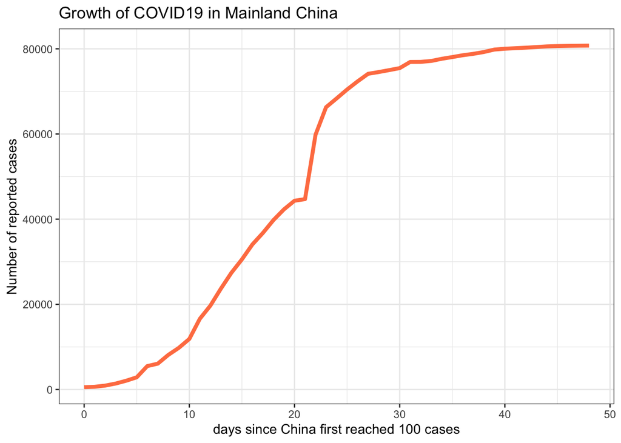

We are interested in how the disease will affect the United States. The US reached over 100 cases on March 3. Shown below is the observed number of cases from March 3 - March 10. The growth seems linear until day 6. To predict the growth rate of the disease in the US and make predictions, we will use a model in which data is shared across countries so that countries with more information, such as China, inform the estimates of other countries’ growth rates.

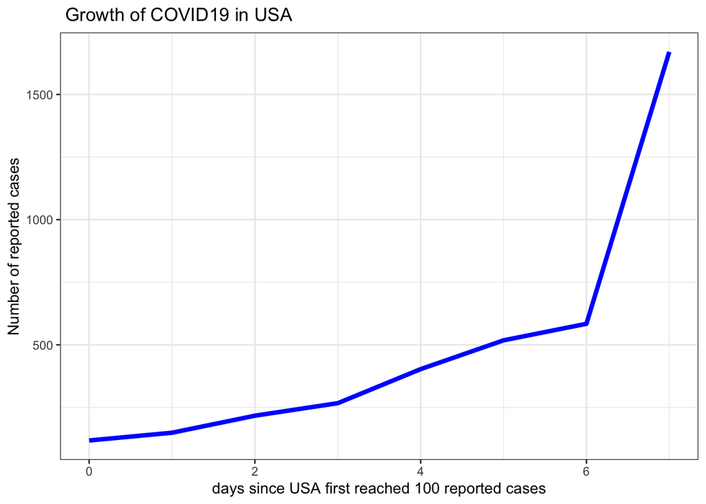

Shown below are the growth rates for all countries excluding China. China has a much higher number of caes over a longer amount of time, so it is difficult to compare on the same scale as the other countries. Japan and Singapore seem to have very flat growth rates, or perhaps very low exponential growth rates. Iran, Korea, and Italy have very high growth rates.

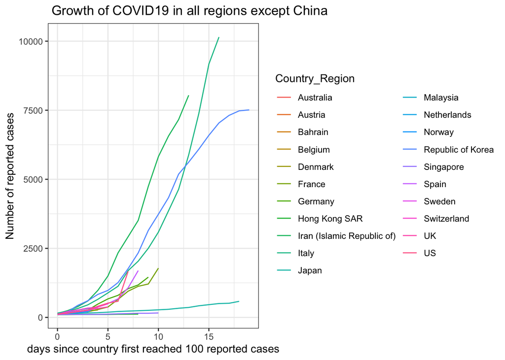

# Estimating global and country-specific growth rates using Bayesian inference

The model states that the number of cases at a given time is exponential with a rate determined by the country-specific growth rate and the time of interest. Since each country has different number of cases at time 0 (the day in which the number of cases >= 100), the rate of the exponential also includes a country-specific offset.

The model:  
C(i,t)=#(cases in region i at t days after first reaching 100 cases)

𝔼[C(i,t)]=exp(ci+rit)

As mentioned above, we also estimate a global growth rate, and this global growth rate is the prior for each country-specific growth rate. This mechanism allows us to share data and thus predictive power across countries.

# Results: Estimated parameters of the exponential growth model

The global growth rate = 0.22, and we are 95% confident that given this data the rate is between 0.17 and 0.27.

Shown below are the posterior credible regions for the other estimates, the country-specific growth rates and the country-specific offsets. The median estimate is shown with a circle, the 75% credible region is shown in bold blue around the median, and the 95% credible region is shown in thin light blue.

Even though China started out with a higher number of cases, its growth rate is one of the lowest.

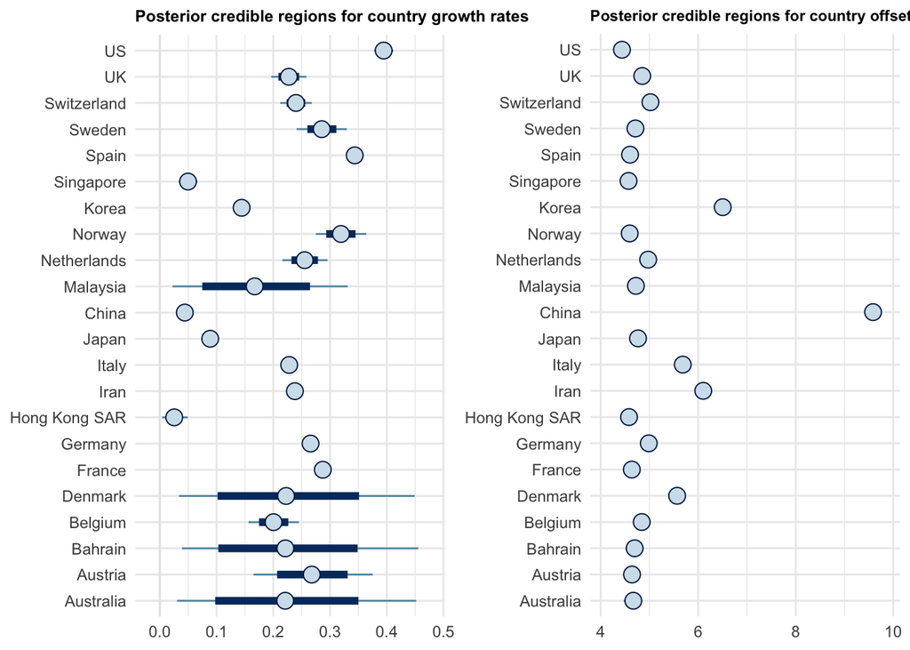

# Simulation with paramaters derived from Stan: Comparison of predicted and true growth in China

The plot below shows the true case counts until March 10 and the predictions for these dates. The disparity between these lines likely comes from the fact that the model I used assumes a constant growth rate through time. This constant growth rate does not reflect reality, since we can see different rates through time, including a plateau in growth at around 28 days. The model also predicts a higher initial number of cases, but I do not know what accounts for this difference in initial case number. The plateau is likely due to the safety measures China implemented, such as self quarentines.

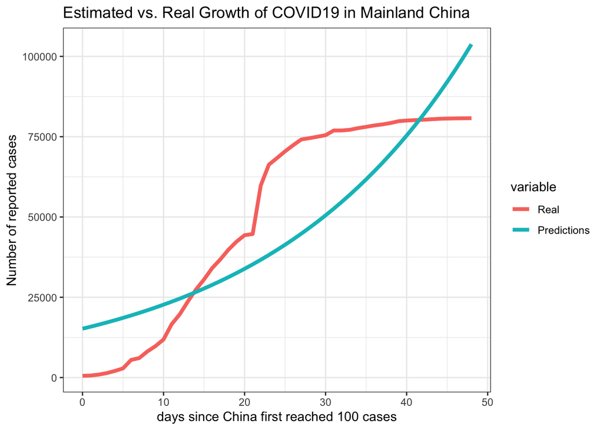

# Predictions: Growth in the United States

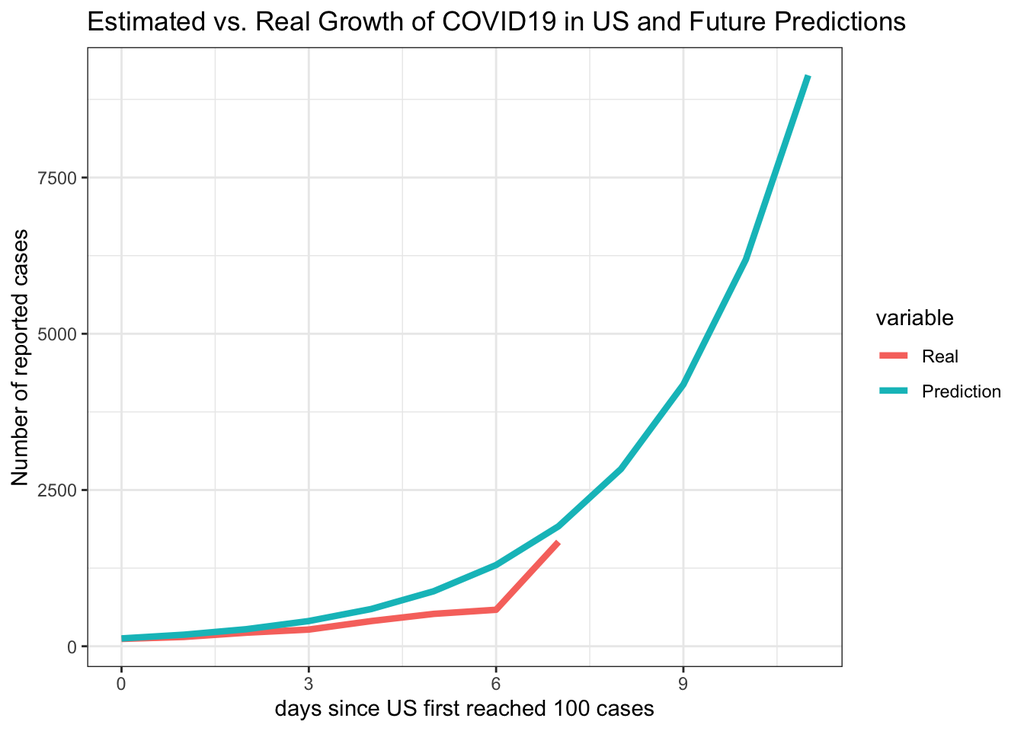

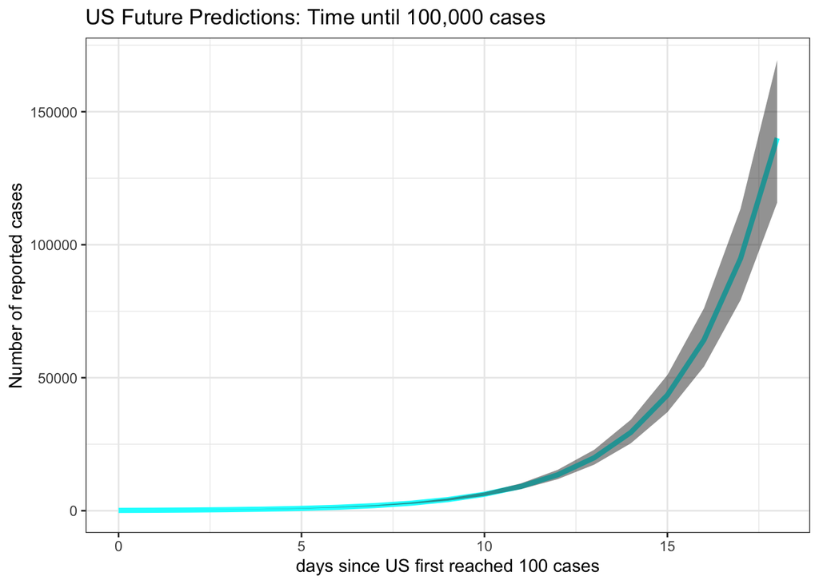

# Discussion of disparity between present case counts and model predictions

There is quite a disparity between the model and reality. One reason for this disparity could be similar to the pattern we saw with the data from China: the model does not incorporate vairable rates over time. Perhaps the inital spread of the disease was higher and then slowed down after recent quarentine and social distancing measures were put in place. However, because the US has not implemented strong isolation measures, I think the reason for the disparity between the real and predicted values may differ from China’s reasons. I think another explanation for the difference between the model and reality in the US is the state of testing for the virus. The US did not begin testing until much later than many other countries. Although the CDC sent tests to select health facilities starting on February 7th, the test was not working for a majority of these facilities. Major testing efforts began around March 6-15th. President Trump announced he would start to offer tests at a larger scale on March 6th. Since then, testing has continually increased, but this increase has not been not gradual. For example, on March 13th, the large pharmaceutical company Roche received approval from the FDA to use automated systems for detecting coronavirus. This likely increased testing dramatically. The saltatory nature of testing likely affects our estimate of the growth rate in the US. With this data, we cannot disentangle the growth of the virus from the growth of testing.

I think an analysis that takes into account the availability of testing in a country would give further insight into the true spread of the disease. For example, we could perhaps give different weights to the country predictors depending on the availability of testing in that country. With this setup, I would weight countries like South Korea and Japan more heavily. Countries like the US would contribute less to the predictions, but we would still be able to share information across all countries like in the current model.